# Clustering and Principal Component Analysis

Hugo Trivino

```r
setwd(".")
set.seed(1122)
options("digits"=3)
library(factoextra)
library(ggplot2)
library(dplyr)
library(cluster)
```

#2.1 Problem 1: K-means clustering

##(a) Data cleanup ###(i) So far I think all the attribute are relevant for the clustering.

```r
text2csv <- function(in.file,out.file) {
  mammals.df <- read.csv(file= in.file,
                           header = FALSE,
                           sep = "",
                           dec = ".",
                           comment.char = "#"

                           )

  write.csv(mammals.df, file = out.file)
  mammals.df <- read.csv(file= out.file,
                           header = TRUE,
                           sep = ",",
                           dec = ".",
                           comment.char = "#",
                         skip = 4
                           )
  write.csv(mammals.df[,2:10], file = out.file,row.names = F)
  mammals.df <- read.csv(out.file,row.names = 1)

  return( mammals.df)
}
mammals.df <- text2csv(in.file = "file19.txt", out.file = "mammals.csv")
summary(mammals.df)
```

```
       I             i              C               c               P              p              M
 Min.   :0.0   Min.   :0.00   Min.   :0.000   Min.   :0.000   Min.   :0.00   Min.   :0.00   Min.   :0.00
 1st Qu.:1.0   1st Qu.:1.00   1st Qu.:0.000   1st Qu.:0.000   1st Qu.:2.00   1st Qu.:1.00   1st Qu.:1.00
 Median :2.0   Median :3.00   Median :1.000   Median :1.000   Median :3.00   Median :3.00   Median :3.00
 Mean   :1.8   Mean   :2.38   Mean   :0.591   Mean   :0.545   Mean   :2.56   Mean   :2.42   Mean   :2.45
 3rd Qu.:3.0   3rd Qu.:3.00   3rd Qu.:1.000   3rd Qu.:1.000   3rd Qu.:3.00   3rd Qu.:3.00   3rd Qu.:3.00
 Max.   :5.0   Max.   :4.00   Max.   :1.000   Max.   :1.000   Max.   :4.00   Max.   :4.00   Max.   :8.00
       m
 Min.   :0.00
 1st Qu.:2.00
 Median :3.00
 Mean   :2.64
 3rd Qu.:3.00
 Max.   :8.00
```

```r
mammals.scaled <- scale(mammals.df)
rm(mammals.df)
```

###(ii) The data is not standardize since the mean is not zero. ###(iii) Data is cleaned in the function text2csv and works for all Hartigan file format, the resulting file is named “mammals.csv”.

##(b) Clustering (2 points divided evenly by components below)

###(i) According to WSS, k = 7 and k=9 are good numbers, but Silhouette indicates that the best cluster number is k=8. However, by analyzing output in part (vi) I realized that k=7 was the best cluster for this application.

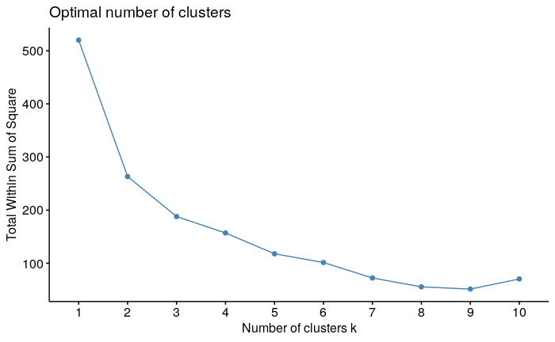

```r
fviz_nbclust(mammals.scaled, kmeans, method="wss") # Elbow method minimizes total
```

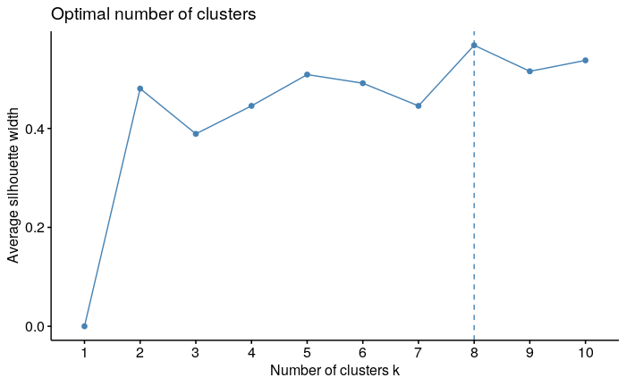

```r
fviz_nbclust(mammals.scaled, kmeans, method="silhouette") # Silhouette method
```

###(ii) Plotting the clusters using fviz_cluster().

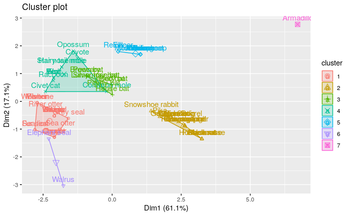

```r
set.seed(1122)
kmu <- kmeans(mammals.scaled, centers=7,nstart=40)
#png(filename="mammalCluster.png", units = "px", width=2000, height=2000)
fviz_cluster(kmu, data=mammals.scaled)
```

```r
#dev.off()
```

###(iii) Table of observations per cluster

```r
obsxclus <-as.data.frame(table(kmu$cluster))
names(obsxclus) <-c("Cluster","Observations")
print(obsxclus)
```

| Cluster | Observations |
| --- | --- |
| 1 | 17 |
| 2 | 19 |
| 3 | 8 |
| 4 | 10 |
| 5 | 9 |
| 6 | 2 |
| 7 | 1 |

```r
rm(obsxclus)
```

###(iv) The total sum of square errors

```r
print(paste("Total SSE :", kmu$tot.withinss))
```

```
[1] "Total SSE : 61.8750144556537"
```

###(v) SSE for each cluster is shown in the following table:

```r
SSExclus <-c()
for (x in 1:max(kmu$cluster)){
  SSExclus <-rbind(SSExclus,c(x,kmu$withinss[x]))
}
colnames(SSExclus) <- c("Cluster", "SSE")
print(SSExclus)
```

```
     Cluster   SSE
[1,]       1 14.92
[2,]       2 15.57
[3,]       3  4.24
[4,]       4 18.58
[5,]       5  6.34
[6,]       6  2.22
[7,]       7  0.00
```

```r
rm(SSExclus,x)
```

###(vi) I started with k=7, then I did k=8, and k=9. I found k=7 to be the best fit according to my limited knowledge of the animal kingdom since the others separate the squirrels in different clusters or the common mole from other mole types. This is my final group separation:

```r
for (x in 1:max(kmu$cluster)){
    cat(paste("Group ",x, ":\n",paste(names(which(kmu$cluster==x)),collapse = ", ")) ,"\n")
}
```

```
Group  1 :
 Marten, Fisher, Weasel, Mink, Ferrer, Wolverine, Badger, Skunk, River otter, Sea otter, Jaguar, Ocelot, Cougar, Lynx, Fur seal, Sea lion, Grey seal
Group  2 :
 Pika, Snowshoe rabbit, Beaver, Marmot, Groundhog, Prairie Dog, Ground Squirrel, Chipmunk, Gray squirrel, Fox squirrel, Pocket gopher, Kangaroo rat, Pack rat, Field mouse, Muskrat, Black rat, House mouse, Porcupine, Guinea pig
Group  3 :
 Brown bat, Silver hair bat, Pigmy bat, House bat, Red bat, Hoary bat, Lump nose bat, Peccary
Group  4 :
 Opossum, Hairy tail mole, Common mole, Star nose mole, Coyote, Wolf, Fox, Bear, Civet cat, Raccoon
Group  5 :
 Elk, Deer, Moose, Reindeer, Antelope, Bison, Mountain goat, Musk ox, Mountain sheep
Group  6 :
 Walrus, Elephant seal
Group  7 :
 Armadillo
```

```r
rm(x)
```

#2.2 Problem 2: Hierarchical clustering

```r
set.seed(1122)
mammals.sample <-sample_n(read.csv("mammals.csv",row.names = 1),size = 35)
```

##(a)Running hierarchical clustering on the data-set using factoextra::eclust() method and using the clustering algorithm for three linkages: single, complete, and average.

```r
hclust.single <- eclust(mammals.sample, FUNcluster = "hclust",hc_method="single")
```

```
Clustering k = 1,2,..., K.max (= 10): .. done
Bootstrapping, b = 1,2,..., B (= 100)  [one "." per sample]:
.................................................. 50
.................................................. 100
```

```r
hclust.complete <- eclust(mammals.sample, FUNcluster = "hclust",hc_method="complete")
```

```
Clustering k = 1,2,..., K.max (= 10): .. done
Bootstrapping, b = 1,2,..., B (= 100)  [one "." per sample]:
.................................................. 50
.................................................. 100
```

```r
hclust.average <- eclust(mammals.sample, FUNcluster = "hclust",hc_method="average")
```

```
Clustering k = 1,2,..., K.max (= 10): .. done
Bootstrapping, b = 1,2,..., B (= 100)  [one "." per sample]:
.................................................. 50
.................................................. 100
```

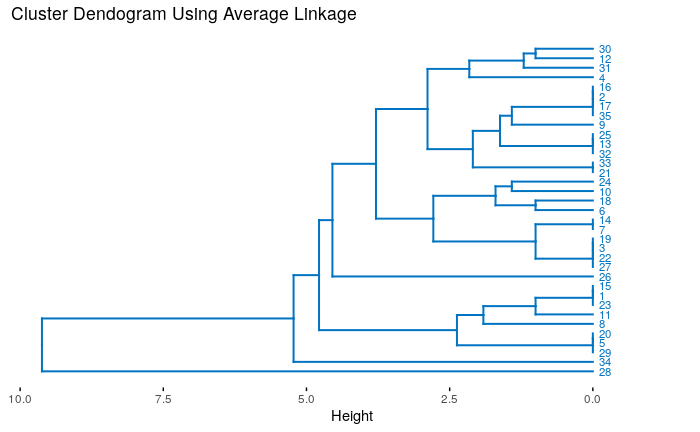

```r
fviz_dend(hclust.average,show_labels=T ,palette="jco",cex = .6, hang=-.5,horiz = T,main = "Cluster Dendogram Using Average Linkage")
```

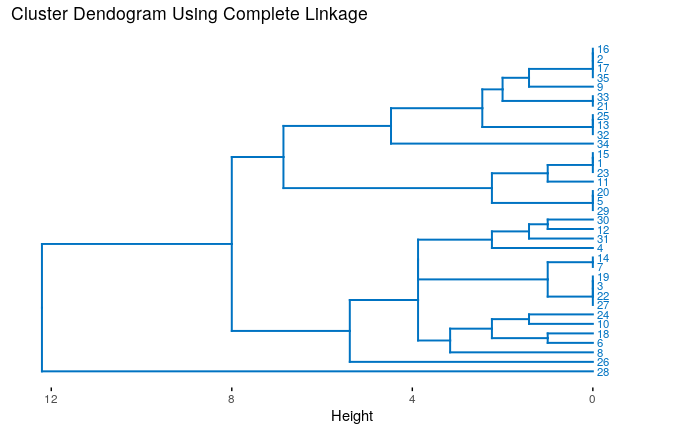

```r
fviz_dend(hclust.complete,show_labels=T ,palette="jco",cex = .6, hang=-.5,horiz = T, main = "Cluster Dendogram Using Complete Linkage")
```

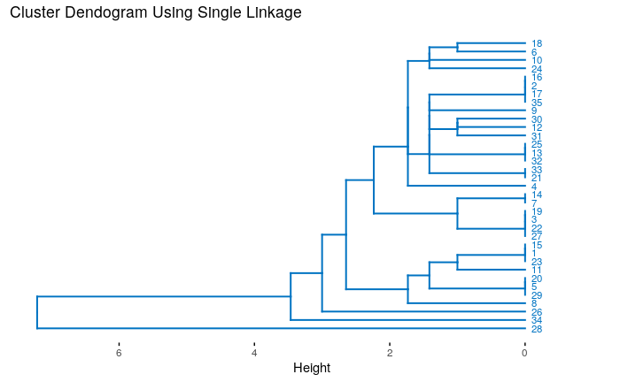

```r
fviz_dend(hclust.single,show_labels=T ,palette="jco",cex = .6, hang=-.5,horiz = T,main = "Cluster Dendogram Using Single Linkage")
```

##(b) Finding the clusters formed by two singleton clusters.

```r
print2sing <- function(hc) {
  for (x in 1:34){
    if(hc$merge[x,1] <0 & hc$merge[x,2] <0){
      cat(paste("\t{",rownames(mammals.sample[ - hc$merge[x,1],] ),
                  ", ",rownames(mammals.sample[ - hc$merge[x,2],] ),"}\n"))
    }
  }
}
cat("Two singleton clusters formed using Single Linkage:\n")
```

```
Two singleton clusters formed using Single Linkage:
```

```r
print2sing(hclust.single)
```

```
    { 1 ,  15 }
    { 2 ,  16 }
    { 3 ,  19 }
    { 5 ,  20 }
    { 7 ,  14 }
    { 13 ,  25 }
    { 21 ,  33 }
    { 6 ,  18 }
    { 12 ,  30 }
```

```r
cat("\nTwo singleton clusters formed using Complete Linkage\n")
```

```
Two singleton clusters formed using Complete Linkage
```

```r
print2sing(hclust.complete)
```

```
    { 1 ,  15 }
    { 2 ,  16 }
    { 3 ,  19 }
    { 5 ,  20 }
    { 7 ,  14 }
    { 13 ,  25 }
    { 21 ,  33 }
    { 6 ,  18 }
    { 12 ,  30 }
    { 10 ,  24 }
```

```r
cat("\nTwo singleton clusters formed using Average Linkage\n")
```

```
Two singleton clusters formed using Average Linkage
```

```r
print2sing(hclust.average)
```

```
    { 1 ,  15 }
    { 2 ,  16 }
    { 3 ,  19 }
    { 5 ,  20 }
    { 7 ,  14 }
    { 13 ,  25 }
    { 21 ,  33 }
    { 6 ,  18 }
    { 12 ,  30 }
    { 10 ,  24 }
```

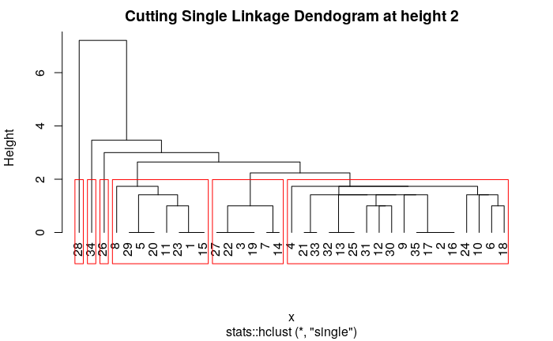

```r
plot(hclust.single,hang = -1,main = "Cutting Single Linkage Dendogram at height 2")
groups <- cutree(hclust.single, h=2)
rect.hclust(hclust.single, h=2, border="red")
```

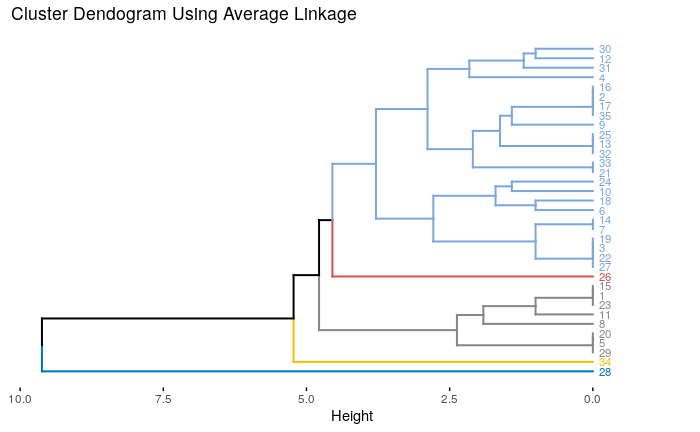

```r
hclust.single <- eclust(mammals.sample, FUNcluster = "hclust",hc_method="single",k=5)
hclust.complete <- eclust(mammals.sample, FUNcluster = "hclust",hc_method="complete",k=5)
hclust.average <- eclust(mammals.sample, FUNcluster = "hclust",hc_method="average",k=5)
fviz_dend(hclust.average,show_labels=T ,palette="jco",cex = .6, hang=-.5,horiz = T,main = "Cluster Dendogram Using Average Linkage")
```

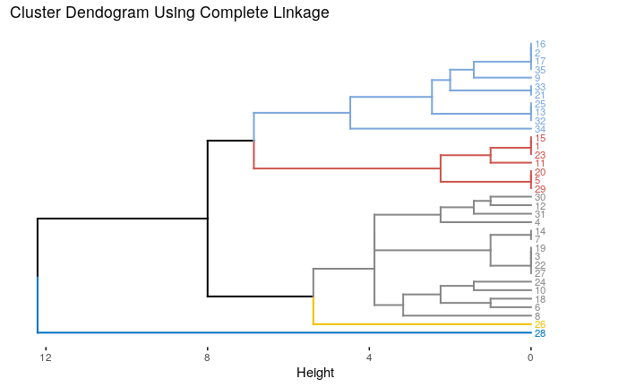

```r
fviz_dend(hclust.complete,show_labels=T ,palette="jco",cex = .6, hang=-.5,horiz = T, main = "Cluster Dendogram Using Complete Linkage")
```

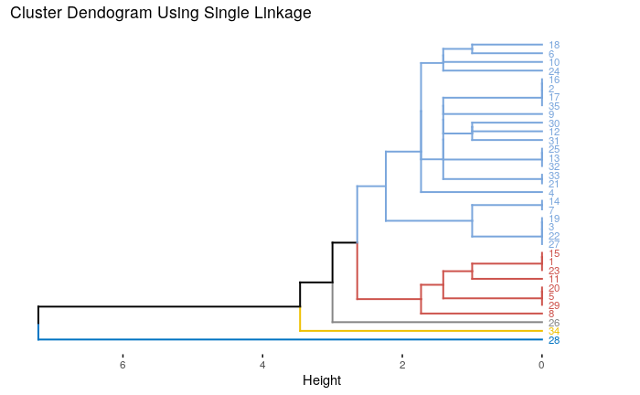

```r
fviz_dend(hclust.single,show_labels=T ,palette="jco",cex = .6, hang=-.5,horiz = T,main = "Cluster Dendogram Using Single Linkage")
```

##(f)Printing the Dunn and Silhouette width using fpc::cluster.stats() for each linkage method.

```r
pDunnSil <-function(clust){
  distance <-dist(scale(mammals.sample))
  tt<-fpc::cluster.stats(distance,clust$cluster)
  cat(paste("Dunn :",tt$dunn," ; Silhouette :",tt$avg.silwidth ,"\n"))
}

print("Printing Dunn and Silhouette for Single linkage")
```

```
[1] "Printing Dunn and Silhouette for Single linkage"
```

```r
pDunnSil(hclust.single)
```

```
Dunn : 0.498311590425928  ; Silhouette : 0.279715105214637
```

```r
print("Printing Dunn and Silhouette for Complete linkage")
```

```
[1] "Printing Dunn and Silhouette for Complete linkage"
```

```r
pDunnSil(hclust.complete)
```

```
Dunn : 0.264284056236123  ; Silhouette : 0.358050645951175
```

```r
print("Printing Dunn and Silhouette for Average linkage")
```

```
[1] "Printing Dunn and Silhouette for Average linkage"
```

```r
pDunnSil(hclust.average)
```

```
Dunn : 0.498311590425928  ; Silhouette : 0.279715105214637
```

```r
rm(hclust.single,hclust.complete,hclust.average)
```

#2.3 Problem 3: K-Means and PCA

```r
set.seed(1122)
htru.df <-read.csv(file = "HTRU_2-small.csv")
htru.pca <- prcomp(scale(htru.df[,1:8]))
```

```r
htru.pca$sdev
```

```
[1] 2.039 1.458 0.898 0.674 0.511 0.398 0.143 0.124
```

```r
summary(htru.df)
```

```
      mean          std.dev        kurtosis        skewness     mean.dm.snr    std.dev.dm.snr
 Min.   :  5.8   Min.   :24.8   Min.   :-1.74   Min.   :-1.8   Min.   :  0.2   Min.   :  7.4
 1st Qu.:100.8   1st Qu.:42.4   1st Qu.: 0.03   1st Qu.:-0.2   1st Qu.:  1.9   1st Qu.: 14.5
 Median :114.9   Median :47.0   Median : 0.22   Median : 0.2   Median :  2.8   Median : 18.6
 Mean   :110.9   Mean   :46.6   Mean   : 0.48   Mean   : 1.8   Mean   : 12.4   Mean   : 26.4
 3rd Qu.:127.0   3rd Qu.:51.1   3rd Qu.: 0.48   3rd Qu.: 0.9   3rd Qu.:  5.6   3rd Qu.: 28.7
 Max.   :189.7   Max.   :91.8   Max.   : 7.88   Max.   :65.4   Max.   :211.9   Max.   :110.6
 kurtosis.dm.snr skewness.dm.snr     class
 Min.   :-2.8    Min.   :  -2    Min.   :0.000
 1st Qu.: 5.7    1st Qu.:  34    1st Qu.:0.000
 Median : 8.4    Median :  82    Median :0.000
 Mean   : 8.3    Mean   : 103    Mean   :0.096
 3rd Qu.:10.7    3rd Qu.: 139    3rd Qu.:0.000
 Max.   :34.5    Max.   :1191    Max.   :1.000
```

##(a) Perform PCA on the dataset and answer the following questions: ###(i) Variance explained by first two components

```r
cat(paste("The first two components explain:\n",
          format(100*sum(htru.pca$sdev[1:2])/sum(htru.pca$sdev),digits=4),
          "% of the variance"
          )
    )
```

```
The first two components explain:
 55.99 % of the variance
```

###(ii) Plotting the first two principal components. Using a different color to represent the observations in the two classes.

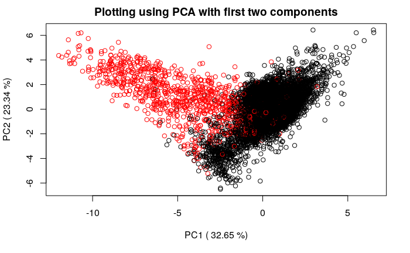

```r
first2 <-htru.pca$x[,1:2]
  plot(first2[,1],
       first2[,2],
       col=rainbow(n=1,v = c( htru.df$class==1,htru.df$class==0)),
       xlab = paste("PC1 (",
                    format(100*sum(htru.pca$sdev[1])/sum(htru.pca$sdev),digits=4),
                    "%)"),
       ylab = paste("PC2 (",
                    format(100*sum(htru.pca$sdev[2])/sum(htru.pca$sdev),digits=4),
                  "%)"),
       main="Plotting using PCA with first two components"
      )
```

##(b) We know that the HTRU2 dataset has two classes. We will now use K-means on the HTRU2 dataset. ###(i) Performing K-means clustering on the dataset with centers = 2, and nstart = 25 and plotting the resulting clusters.

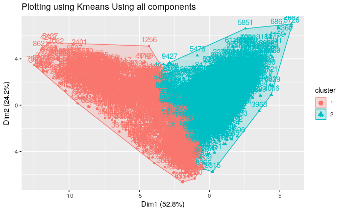

```r
khtwu<- kmeans(scale(htru.df[,1:8]), centers=2,nstart=25)
fviz_cluster(khtwu,
             data=scale(htru.df),
             main="Plotting using Kmeans Using all components")
```

###(ii) The shape of the clusters looks fairly similar since the majority of the variance that is explained in Kmeans using all attributes is also explained in PCA using the first attributes only (after axis rotation). This shows why dimensionality reduction is possible although there is an important lost of variance, the PCA clustering still have some predictive power.

###(iii) What is the distribution of the observations in each cluster?

```r
cat(paste0("In the Left  cluster (2), the percentage of observations is: ",
          format(100*sum(khtwu$cluster==2)/sum(khtwu$cluster==khtwu$cluster),digits=5)," %\n",
          "In the Right cluster (1), the percentage of observations is: ",
          format(100*sum(khtwu$cluster==1)/sum(khtwu$cluster==khtwu$cluster),digits=5)," %\n"))
```

```
In the Left  cluster (2), the percentage of observations is: 88.47 %
In the Right cluster (1), the percentage of observations is: 11.53 %
```

###(iv) What is the distribution of the classes in the HTRU2 dataset?

```r
cat(paste0("The 'TRUE'  class label percentage of observations is:  ",
          format(100*sum(htru.df$class==1)/sum(htru.df$class==htru.df$class),digits=5),
          " %\n",
          "The 'FALSE' class label percentage of observations is: ",
          format(100*sum(htru.df$class==0)/sum(htru.df$class==htru.df$class),digits=5),
          " %\n"
          )
    )
```

```
The 'TRUE'  class label percentage of observations is:  9.59 %
The 'FALSE' class label percentage of observations is: 90.41 %
```

###(vi)

```r
cat(paste0("From the larger cluster, ",
           format(100*sum(htru.df[which(khtwu$cluster==1),9]==0)/sum(khtwu$cluster==1),
                  digits=4),
           " % belong to the majority class (0), while only ",
           format(100*sum(htru.df[which(khtwu$cluster==1),9]==1)/sum(khtwu$cluster==1),
                  digits=4),
           " % belong to the minority class (1)"
           )
    )
```

[output not shown]

```r
tn <- 100*sum(htru.df[which(khtwu$cluster==1),9]==0)
fn <- 100*sum(htru.df[which(khtwu$cluster==1),9]==1)
tp <- 100*sum(htru.df[which(khtwu$cluster==2),9]==1)
fp <- 100*sum(htru.df[which(khtwu$cluster==2),9]==0)
cat(paste0(
        "As a predictive model, it presents the following results:\n\taccuracy\t: ",
        format(100*(tn+tp)/(tp+tn+fp+fn),digits=4),
        "%\n\tError rate\t: ",
        format(100*(fn+fp)/(tp+tn+fp+fn),digits=4),
        "%\n\tPresicion\t: ",
        format(100*(tn)/(tn+fp),digits=4),
        "%\n\tSpecificity\t: ",
        format(100*(tp)/(tp+fp),digits=4),
        "%\n\t\tThis results are given that the positive class was the minority class (1)",
        "\nAlso, the balance accuracy (",
        format(100*((tp)/(tp+fp)+(tn)/(tn+fp))/2,digits=4)        ,
        "%) is pretty good for such an imbalanced sample: "
    )
)
```

```
As a predictive model, it presents the following results:
    accuracy    : 6.4%
    Error rate  : 93.6%
    Presicion   : 4.612%
    Specificity : 2.521%
        This results are given that the positive class was the minority class (1)
Also, the balance accuracy (3.566%) is pretty good for such an imbalanced sample:
```

```r
rm(tn,fn,tp,fp)
```

```r
  #htru.dist <-dist(scale(htru.df[,1:8]))
  #clusStats<-fpc::cluster.stats(htru.dist,khtwu$cluster)
```

###(viii)

```r
  cat(paste0("The total Variance explained by the clustering is : ",
            format(100*(khtwu$tot.withinss/khtwu$totss),digits=4),
            " %")
  )
```

```
The total Variance explained by the clustering is : 64.13 %
```

###(ix)

```r
#cat(paste("Average Silhouette width of both of the cluster is:",format(clusStats$avg.silwidth,digits=4) ,"\n"))
silho<-silhouette(khtwu$cluster, dist(scale(htru.df[,1:8])))
cat(paste0("The average Silhouette width of both of the clusters is: ",
           format(sum(silho[,3])/sum(silho[,1]==silho[,1]),digits=4)
           )
    )
```

```
The average Silhouette width of both of the clusters is: 0.6007
```

```r
for (x in 1:2){
  cat(paste0("The average Silhouette width of Cluster ",x," is: ",
           format(sum(silho[which(silho[,1]==x),3])/sum(silho[,1]==x),digits=4)
           ,"\n"
           )
    )
}
```

```
The average Silhouette width of Cluster 1 is: 0.1516
The average Silhouette width of Cluster 2 is: 0.6592
```

```r
#print("Average Silhouette width per cluster")
#clusStats$clus.avg.silwidths
```

##(c) Performing K-means on the result of the PCA in (a). Using only the first two principal component score vectors.

```r
set.seed(1122)
khtwu<- kmeans(scale(htru.pca$x[,1:2]), centers=2,nstart=25)
```

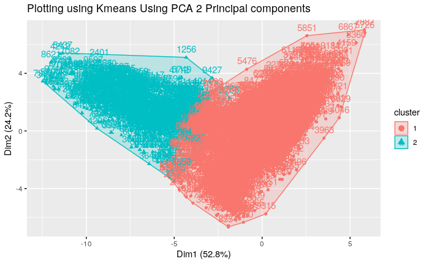

```r
fviz_cluster(khtwu,
             data=scale(htru.df),
             main="Plotting using Kmeans Using PCA 2 Principal components")
```

###(ii) Average Silhouette width for both clusters?

```r
silho<-silhouette(khtwu$cluster, dist(scale(htru.pca$x[,1:8])))
cat(paste0("The average Silhouette width of both of the clusters is: ",
           format(sum(silho[,3])/sum(silho[,1]==silho[,1]),digits=4)
           )
    )
```

```
The average Silhouette width of both of the clusters is: 0.4292
```

```r
for (x in 1:2){
  cat(paste0("The average Silhouette width of cluster ",x," is: ",
           format(sum(silho[which(silho[,1]==x),3])/sum(silho[,1]==x),digits=4)
           ,"\n"
           )
    )
}
```

```
The average Silhouette width of cluster 1 is: 0.4521
The average Silhouette width of cluster 2 is: 0.08426
```

###(iv) All Silhouette values in part C are smaller than the Silhouette values in part B. However, the general tendencies are roughly the same (The centroids are exchanged in this case too). This indicate that although dimensionality reduction takes a great deal of variance and quality of the clusters, it still provides the same information about general tendencies.

```r
rm(list=ls())
```